# Peer-graded Assignment: Prediction Assignment Writeup

Anthony Macey

11 December 2017

# 1 Executive Summary

Using devices such as Jawbone Up, Nike FuelBand, and Fitbit it is now possible to collect a large amount of data about personal activity relatively inexpensively. These type of devices are part of the quantified self movement - a group of enthusiasts who take measurements about themselves regularly to improve their health, to find patterns in their behavior, or because they are tech geeks. One thing that people regularly do is quantify how much of a particular activity they do, but they rarely quantify how well they do it. In this project, your goal will be to use data from accelerometers on the belt, forearm, arm, and dumbell of 6 participants. They were asked to perform barbell lifts correctly and incorrectly in 5 different ways. More information is available from the website [here](http://web.archive.org/web/20161224072740/http:/groupware.les.inf.puc-rio.br/har) (see the section on the Weight Lifting Exercise Dataset).

## 1.1 Data

The training data for this project are available [here](https://d396qusza40orc.cloudfront.net/predmachlearn/pml-training.csv)

The test data are available [here](https://d396qusza40orc.cloudfront.net/predmachlearn/pml-testing.csv)

# 2 Processing

## 2.1 Load the Required Packages

```r
knitr::opts_chunk$set(echo = TRUE)
options(width=120)
library(caret)
library(pander)
library(randomForest)
library(corrplot)
```

## 2.2 Load & Cache the Data

```r
training.data <- read.csv("https://d396qusza40orc.cloudfront.net/predmachlearn/pml-training.csv")
testing.data <- read.csv("https://d396qusza40orc.cloudfront.net/predmachlearn/pml-testing.csv")
```

## 2.3 Create a Partition with The Training Set

```r
in.train  <- createDataPartition(training.data$classe, p=0.7, list=FALSE)
training.data.cl <- training.data[in.train, ]
testing.data.cl  <- training.data[-in.train, ]
```

## 2.4 Remove Remove The Near-Zero Variance Predictors

```r
nzv <- nearZeroVar(training.data.cl, saveMetrics = T)
training.data.cl <- training.data.cl[, !nzv$nzv]
testing.data.cl <- testing.data.cl[, !nzv$nzv]
```

## 2.5 Remove Columns That Have NA’s

```r
nas <- (colSums(is.na(training.data.cl)) == 0)
training.data.cl <- training.data.cl[, nas]
testing.data.cl <- testing.data.cl[, nas]
```

## 2.6 Remove the User & Time Data

```r
training.data.cl <- training.data.cl[ , -c(1:5)]
testing.data.cl <- testing.data.cl[ , -c(1:5)]
```

# 3 Modeling - Prediction Model Building

## 3.1 Verifying Correlation Analysis

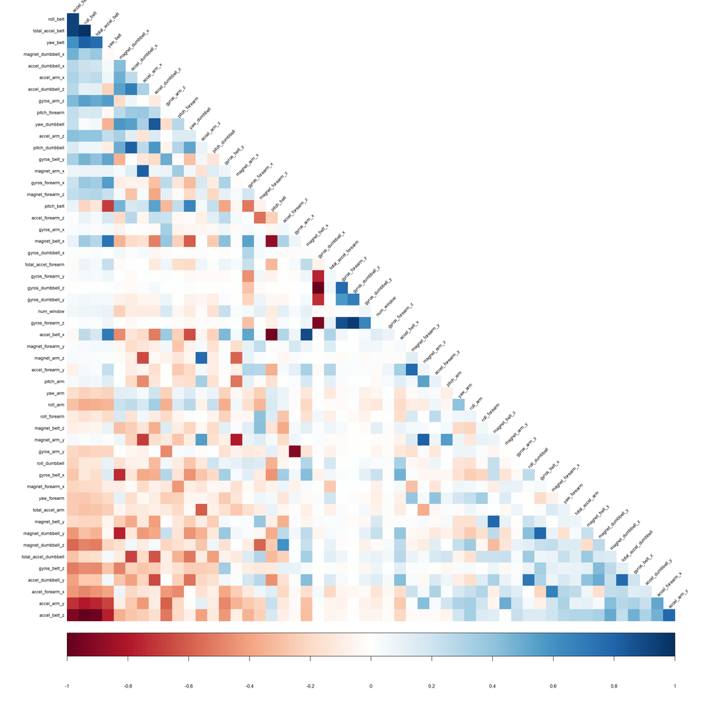

```r
cor.matrix <- cor(training.data.cl[, -54])
corrplot(cor.matrix, order="FPC", tl.cex=0.75, method="color", tl.col="black", tl.srt = 45, type="lower", diag = FALSE)
```

## 3.2 Model Selection

The highly correlated variables are shown in dark colours in the graph above. A PCA analysis wont be performed due to the rather sparse nature of the correlations.

Both a GBM and RF model will be trained and the the results compared.

## 3.3 Train a Generalised Boosted Model

```r
set.seed(45235)

GBM.ctl <-
  trainControl(method = "repeatedcv",
               number = 5,
               repeats = 1)

GBM.fit  <-
  train(
    classe ~ .,
    data = training.data.cl,
    method = "gbm",
    trControl = GBM.ctl,
    verbose = FALSE
  )

GBM.fit$finalModel
```

```
## A gradient boosted model with multinomial loss function.
## 150 iterations were performed.
## There were 53 predictors of which 41 had non-zero influence.
```

## 3.4 Verify the GBM Model

```r
GBM.predict <- predict(GBM.fit, newdata = testing.data.cl)
GBM.cfx <- confusionMatrix(GBM.predict, testing.data.cl$classe)
GBM.cfx
```

```
## Confusion Matrix and Statistics
##
##           Reference
## Prediction    A    B    C    D    E
##          A 1667   19    0    0    0
##          B    7 1098   15    2    3
##          C    0   21 1009   17    3
##          D    0    1    2  944   13
##          E    0    0    0    1 1063
##
## Overall Statistics
##
##                Accuracy : 0.9823
##                  95% CI : (0.9786, 0.9855)
##     No Information Rate : 0.2845
##     P-Value [Acc > NIR] : < 2.2e-16
##
##                   Kappa : 0.9776
##  Mcnemar's Test P-Value : NA
##
## Statistics by Class:
##
##                      Class: A Class: B Class: C Class: D Class: E
## Sensitivity            0.9958   0.9640   0.9834   0.9793   0.9824
## Specificity            0.9955   0.9943   0.9916   0.9967   0.9998
## Pos Pred Value         0.9887   0.9760   0.9610   0.9833   0.9991
## Neg Pred Value         0.9983   0.9914   0.9965   0.9959   0.9961
## Prevalence             0.2845   0.1935   0.1743   0.1638   0.1839
## Detection Rate         0.2833   0.1866   0.1715   0.1604   0.1806
## Detection Prevalence   0.2865   0.1912   0.1784   0.1631   0.1808
## Balanced Accuracy      0.9957   0.9792   0.9875   0.9880   0.9911
```

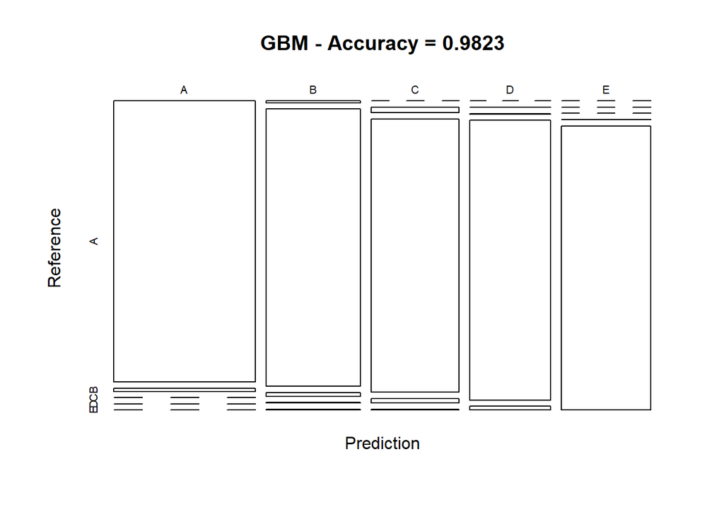

```r
plot(GBM.cfx$table,
     col = GBM.cfx$byClass,
     main = paste("GBM - Accuracy =", round(GBM.cfx$overall['Accuracy'], 4)))
```

## 3.5 Train a Random Forest Model

```r
set.seed(45235)
random.forest.ctl <-
  trainControl(method = "cv",
               number = 3,
               verboseIter = FALSE)

random.forest.fit <-
  train(classe ~ .,
        data = training.data.cl,
        method = "rf",
        trControl = random.forest.ctl)

random.forest.fit$finalModel
```

```
##
## Call:
##  randomForest(x = x, y = y, mtry = param$mtry)
##                Type of random forest: classification
##                      Number of trees: 500
## No. of variables tried at each split: 27
##
##         OOB estimate of  error rate: 0.23%
## Confusion matrix:
##      A    B    C    D    E  class.error
## A 3904    1    0    0    1 0.0005120328
## B    9 2647    2    0    0 0.0041384500
## C    0    4 2391    1    0 0.0020868114
## D    0    0    8 2244    0 0.0035523979
## E    0    1    0    5 2519 0.0023762376
```

## 3.6 Verify the Random Forest Model

```r
random.forest.predict <-
  predict(random.forest.fit, newdata = testing.data.cl)
random.forest.cfx <-
  confusionMatrix(random.forest.predict, testing.data.cl$classe)
random.forest.cfx
```

```
## Confusion Matrix and Statistics
##
##           Reference
## Prediction    A    B    C    D    E
##          A 1674    3    0    0    0
##          B    0 1136    4    0    0
##          C    0    0 1022    4    0
##          D    0    0    0  959    4
##          E    0    0    0    1 1078
##
## Overall Statistics
##
##                Accuracy : 0.9973
##                  95% CI : (0.9956, 0.9984)
##     No Information Rate : 0.2845
##     P-Value [Acc > NIR] : < 2.2e-16
##
##                   Kappa : 0.9966
##  Mcnemar's Test P-Value : NA
##
## Statistics by Class:
##
##                      Class: A Class: B Class: C Class: D Class: E
## Sensitivity            1.0000   0.9974   0.9961   0.9948   0.9963
## Specificity            0.9993   0.9992   0.9992   0.9992   0.9998
## Pos Pred Value         0.9982   0.9965   0.9961   0.9958   0.9991
## Neg Pred Value         1.0000   0.9994   0.9992   0.9990   0.9992
## Prevalence             0.2845   0.1935   0.1743   0.1638   0.1839
## Detection Rate         0.2845   0.1930   0.1737   0.1630   0.1832
## Detection Prevalence   0.2850   0.1937   0.1743   0.1636   0.1833
## Balanced Accuracy      0.9996   0.9983   0.9976   0.9970   0.9980
```

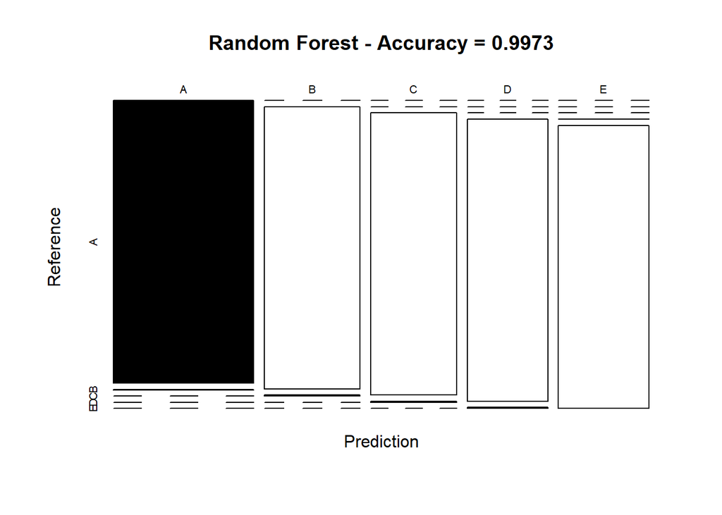

```r
plot(
  random.forest.cfx$table,
  col = random.forest.cfx$byClass,
  main = paste(
    "Random Forest - Accuracy =",
    round(random.forest.cfx$overall['Accuracy'], 4)
  )
)
```